# Peer-graded Assignment: Regression Models Course Project

2. Classification Trees

The classification trees method is known to be easy to intepret and better for non-linear relationships.

```r
modeltree<-train(classe~.,method='rpart',data=training1)
treepredict<-predict(modeltree,validation)
confusionMatrix(treepredict,validation$classe)
```

```
## Confusion Matrix and Statistics
##
##           Reference
## Prediction    A    B    C    D    E
##          A 1297  326   32   52   12
##          B    4  192    1    0    0
##          C  251  222  873  440  305
##          D  120  399  120  472  278
##          E    2    0    0    0  487
##
## Overall Statistics
##
##                Accuracy : 0.5643
##                  95% CI : (0.5515, 0.577)
##     No Information Rate : 0.2845
##     P-Value [Acc > NIR] : < 2.2e-16
##
##                   Kappa : 0.4517
##
##  Mcnemar's Test P-Value : NA
##
## Statistics by Class:
##
##                      Class: A Class: B Class: C Class: D Class: E
## Sensitivity            0.7748  0.16857   0.8509   0.4896  0.45009
## Specificity            0.8998  0.99895   0.7493   0.8137  0.99958
## Pos Pred Value         0.7545  0.97462   0.4175   0.3398  0.99591
## Neg Pred Value         0.9095  0.83351   0.9597   0.8906  0.88973
## Prevalence             0.2845  0.19354   0.1743   0.1638  0.18386
## Detection Rate         0.2204  0.03263   0.1483   0.0802  0.08275
## Detection Prevalence   0.2921  0.03347   0.3553   0.2360  0.08309
## Balanced Accuracy      0.8373  0.58376   0.8001   0.6516  0.72484
```

```r
troutofsample<-1-confusionMatrix(treepredict,validation$classe)$overall[1]
troutofsample[[1]]
```

```
## [1] 0.4356839
```

As we can see, the accuracy of the model here is lower than that of the LDA model, while the estimated out of sample error is higher.

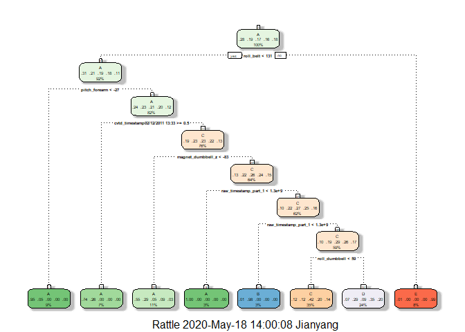

```r
fancyRpartPlot(modeltree$finalModel)
```

3. Random Forests

The random forests model is known to be accurate but difficult to intepret and computationally slow.

```r
modelrf<-train(classe~.,method='rf',data=training1)
rfpredict<-predict(modelrf,validation)
confusionMatrix(rfpredict,validation$classe)
```

```
## Confusion Matrix and Statistics
##
##           Reference
## Prediction    A    B    C    D    E
##          A 1674    0    0    0    0
##          B    0 1139    1    0    0
##          C    0    0 1025    0    0
##          D    0    0    0  964    1
##          E    0    0    0    0 1081
##
## Overall Statistics
##
##                Accuracy : 0.9997
##                  95% CI : (0.9988, 1)
##     No Information Rate : 0.2845
##     P-Value [Acc > NIR] : < 2.2e-16
##
##                   Kappa : 0.9996
##
##  Mcnemar's Test P-Value : NA
##
## Statistics by Class:
##
##                      Class: A Class: B Class: C Class: D Class: E
## Sensitivity            1.0000   1.0000   0.9990   1.0000   0.9991
## Specificity            1.0000   0.9998   1.0000   0.9998   1.0000
## Pos Pred Value         1.0000   0.9991   1.0000   0.9990   1.0000
## Neg Pred Value         1.0000   1.0000   0.9998   1.0000   0.9998
## Prevalence             0.2845   0.1935   0.1743   0.1638   0.1839
## Detection Rate         0.2845   0.1935   0.1742   0.1638   0.1837
## Detection Prevalence   0.2845   0.1937   0.1742   0.1640   0.1837
## Balanced Accuracy      1.0000   0.9999   0.9995   0.9999   0.9995
```

```r
rfoutofsample<-1-confusionMatrix(rfpredict,validation$classe)$overall[1]
rfoutofsample[[1]]
```

```
## [1] 0.0003398471
```

As we can see, the accuracy of the model here is higher than the LDA and classification trees methods, and the estimated out of sample error is also lower.

4. Boosting with Trees

Boosting with trees helps to create a stronger predictor by weighing weak predictors and adding them up. Hence, it is known to be accurate but is computationally slow.

```r
modelbt<-train(classe~.,method='gbm',data=training1,verbose=FALSE)
btpredict<-predict(modelbt,validation)
confusionMatrix(btpredict,validation$classe)
```

```
## Confusion Matrix and Statistics
##
##           Reference
## Prediction    A    B    C    D    E
##          A 1674    0    0    0    0
##          B    0 1137    1    0    0
##          C    0    0 1019    0    0
##          D    0    2    6  961    5
##          E    0    0    0    3 1077
##
## Overall Statistics
##
##                Accuracy : 0.9971
##                  95% CI : (0.9954, 0.9983)
##     No Information Rate : 0.2845
##     P-Value [Acc > NIR] : < 2.2e-16
##
##                   Kappa : 0.9963
##
##  Mcnemar's Test P-Value : NA
##
## Statistics by Class:
##
##                      Class: A Class: B Class: C Class: D Class: E
## Sensitivity            1.0000   0.9982   0.9932   0.9969   0.9954
## Specificity            1.0000   0.9998   1.0000   0.9974   0.9994
## Pos Pred Value         1.0000   0.9991   1.0000   0.9867   0.9972
## Neg Pred Value         1.0000   0.9996   0.9986   0.9994   0.9990
## Prevalence             0.2845   0.1935   0.1743   0.1638   0.1839
## Detection Rate         0.2845   0.1932   0.1732   0.1633   0.1830
## Detection Prevalence   0.2845   0.1934   0.1732   0.1655   0.1835
## Balanced Accuracy      1.0000   0.9990   0.9966   0.9971   0.9974
```

```r
btoutofsample<-1-confusionMatrix(btpredict,validation$classe)$overall[1]
btoutofsample[[1]]
```

```
## [1] 0.0028887
```

As we can see, the accuracy of the model here is high but lower than that of the random forests model, and the estimated out of sample error is low but higher than that of the random forests model.

### Conclusion

The random forests model (rf) is best in terms of accuracy, hence I decide to use that model to predict on newtesting.

```r
finalpredict<-predict(modelrf,newtesting)
finalpredict
```

```
##  [1] B A B A A E D B A A B C B A E E A B B B
## Levels: A B C D E
```